# Project 2

## Ryder Davis rkd473

The dataset I selected was one from the carData package called Arrests, which is about information regarding marijuana arrests. The variables are released, colour (race), year, age, sex, employed (Y/N), citizen (Y/N), and checks. Most of these are intuitive, and the ones that aren’t are released, which is if the arrestee was released with a summons, and checks, which is the number of police data bases the arrestee’s name was on.

```r
data<-Arrests
man1<-manova(cbind(year,age,checks)~colour, data=data)
summary(man1)
```

```
##             Df   Pillai approx F num Df den Df    Pr(>F)
## colour       1 0.031688   56.962      3   5222 < 2.2e-16 ***
## Residuals 5224
## ---
## Signif. codes:  0 '***' 0.001 '**' 0.01 '*' 0.05 '.' 0.1 ' ' 1
```

```r
summary.aov(man1)
```

```
##  Response year :
##               Df  Sum Sq Mean Sq F value Pr(>F)
## colour         1     0.2 0.19974  0.1034 0.7479
## Residuals   5224 10095.8 1.93259
##
##  Response age :
##               Df Sum Sq Mean Sq F value    Pr(>F)
## colour         1   1637 1637.47   23.78 1.112e-06 ***
## Residuals   5224 359713   68.86
## ---
## Signif. codes:  0 '***' 0.001 '**' 0.01 '*' 0.05 '.' 0.1 ' ' 1
##
##  Response checks :
##               Df  Sum Sq Mean Sq F value    Pr(>F)
## colour         1   366.3  366.33   159.3 < 2.2e-16 ***
## Residuals   5224 12012.9    2.30
## ---
## Signif. codes:  0 '***' 0.001 '**' 0.01 '*' 0.05 '.' 0.1 ' ' 1
```

```r
pairwise.t.test(data$age,data$colour,p.adj="none")
```

```
##
##  Pairwise comparisons using t tests with pooled SD
##
## data:  data$age and data$colour
##
##       Black
## White 1.1e-06
##
## P value adjustment method: none
```

```r
pairwise.t.test(data$checks,data$colour,p.adj="none")
```

```
##
##  Pairwise comparisons using t tests with pooled SD
##
## data:  data$checks and data$colour
##
##       Black
## White <2e-16
##
## P value adjustment method: none
```

```r
1-((.95)^6)
```

```
## [1] 0.2649081
```

```r
.05/6
```

```
## [1] 0.008333333
```

The MANOVA results had a very small p value, indicating that for at least 1 numeric variable, at least 1 colour mean was different. Looking at the ANOVA results, age and checks had at least 1 colour where the mean was different, and the all colour means for year were not significantly different. There were only two groups in the variable colour, so the post-hoc tests would be the same as the ANOVA. Anyways, if we included these in the total tests performed, it would be 6 total tests(1 MANOVA, 3 ANOVA, 2 t-tests), so the probability of making at least one type I error is 0.265, and the boneferroni adjusted p-value to be used would be 0.0083. After this correction, age and checks were still significantly different across colour(black and white). The assumptions are random samples and independant observations, multivariate normality of dependant variables, omogeneity of within-group covariance matrices, linear relationships among dependant variables, no extreme univariate or multivariate outliers, and no multicollinearity. This is a lot of assumptions, so they are likely not all met.

Next, I’m going to test if men have a different number of checks (appearances in police data bases) than women. My null hypothesis is that the checks of men and women will be the same. My alternative hypothesis is that the checks of men will be different than the checks of women.

```r
data%>%group_by(sex)%>%summarize(means=mean(checks))%>%summarize(mean_diff=diff(means))
```

```
## # A tibble: 1 x 1
##   mean_diff
##       <dbl>
## 1     0.594
```

```r
rand_dist<-vector()
for(i in 1:5000){
new<-data.frame(checks=sample(data$checks),sex=data$sex)
rand_dist[i]<-mean(new[new$sex=="Female",]$checks)-
              mean(new[new$sex=="Male",]$checks)
}

mean(rand_dist)*2  #p-value
```

```
## [1] 0.0004394363
```

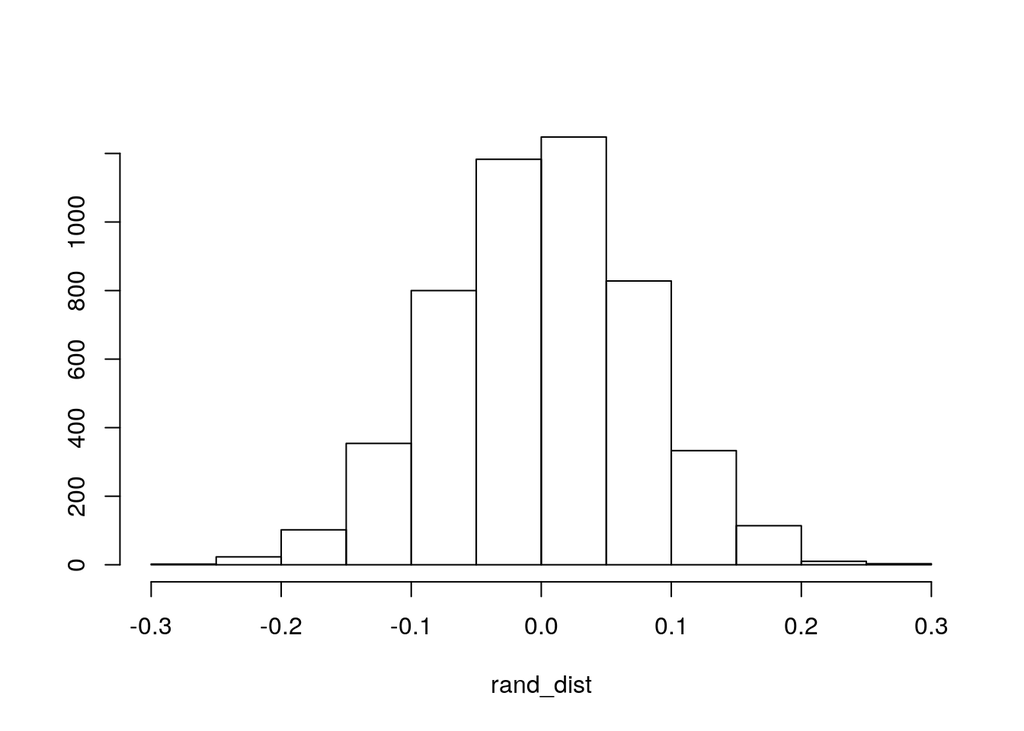

```r
hist(rand_dist,main="",ylab=""); abline(v = 0.594,col="red")
```

```r
centdat<-data%>%mutate_if(is.numeric, function(x)x-mean(x))

fit<-lm(checks~colour*age, data= centdat)
summary(fit)
```

```
##
## Call:
## lm(formula = checks ~ colour * age, data = centdat)
##
## Residuals:
##     Min      1Q  Median      3Q     Max
## -2.5071 -1.3302 -0.3021  1.1654  4.1374
##
## Coefficients:
##                  Estimate Std. Error t value Pr(>|t|)
## (Intercept)      0.454247   0.042152  10.776  < 2e-16 ***
## colourWhite     -0.596692   0.048491 -12.305  < 2e-16 ***
## age              0.008887   0.004873   1.824 0.068276 .
## colourWhite:age  0.019136   0.005682   3.368 0.000764 ***
## ---
## Signif. codes:  0 '***' 0.001 '**' 0.01 '*' 0.05 '.' 0.1 ' ' 1
##
## Residual standard error: 1.503 on 5222 degrees of freedom
## Multiple R-squared:  0.04698,    Adjusted R-squared:  0.04644
## F-statistic: 85.81 on 3 and 5222 DF,  p-value: < 2.2e-16
```

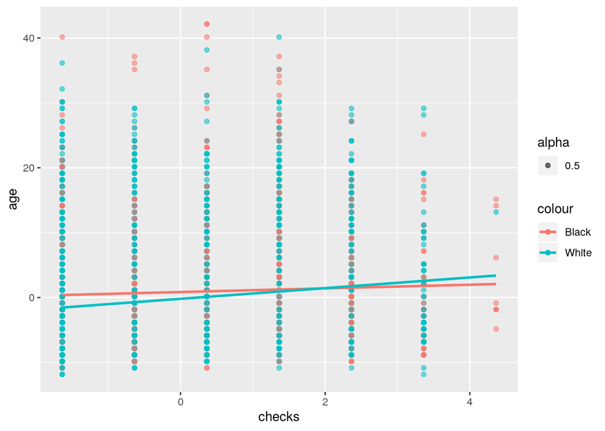

```r
centdat%>%ggplot(aes(checks,age,color=colour))+geom_point(aes(alpha=0.5))+geom_smooth(method = 'lm',se=F)
```